# Balance in Pokemon Games

# Stat Distributions by Generation

Pokemon are also classified by Generation - Each generation ranges from around 90 to 150 Pokemon, and represent about 2-5 year gap between previous generation releases. Determining if Pokemon are balanced across generations is a significant point of analysis, particularly because in video game series, game critics will point out how as time progresses, new characters (or Pokemon in this case) will sometimes steadily increase in power level which renders older characters/Pokemon obsolete (a phenomenon known as "powercreeping").

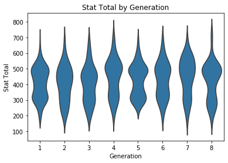

```python
sb.violinplot(data=pokemon,x='generation',y='total_points',color=base_color,inner=None)
plt.ylabel('Stat Total')
plt.xlabel('Generation')
plt.title('Stat Total by Generation');
```

We can sort of see a small powercreep trend in Generations 1-4, noting that in Generation 4, there is a higher proportion of Pokemon resting in the higher peak range of stat totals as opposed to Generation 1 which was a more even bimodal distribution. However, you can immediately notice that this actually rebalanced in Generation 5, and then when a similar powercreep occurred from Generation 5 to Generations 6 and 7, Generation 8 rebalanced the distribution once more. These observations strongly support our balance claim by demonstrating that even in the presence of naturally occurring trends that push games to fall out of balance, Pokemon is actually quite diligent about recalibrating balance without letting something like powercreep go unchecked.

# Special Pokemon Status by Generations

Now because we've established that "Special" Pokemon (Pokemons with the Sub Legendary, Legendary, or Mythical status) are inherently stronger than Normal Pokemon, we'd like to see if these Pokemon are fairly spread across the generations.

Note that our analysis thus far already suggests that this is likely the case, since the presence of too many of these Special Pokemon in one particular generation should've likely skewed the Stat vs Generation visualization we showed in the previous section towards the higher end.

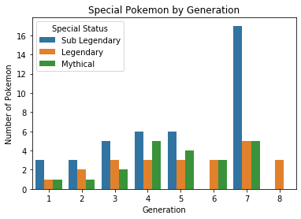

```python
g = sb.countplot(data = pokemon, x = 'generation', hue = 'special_status');
plt.ylabel('Number of Pokemon')
plt.xlabel('Generation')
plt.title('Special Pokemon by Generation')
g.legend(title='Special Status');
```

For Generation and Pokemon Status, we can see that there were more special Pokemon added in the progression from Generation 1 to Generation 4, but then this stabilized going into Generations 5 and 6. Generation 7 showed a peak number of Sub Legendaries, but this was immediately remedied in Generation 8, which has the lowest number of Special Pokemon to date with just 3. This balancing trend is similar to the powercreeping balance we observed in the previous section.

# Special Pokemon by Type

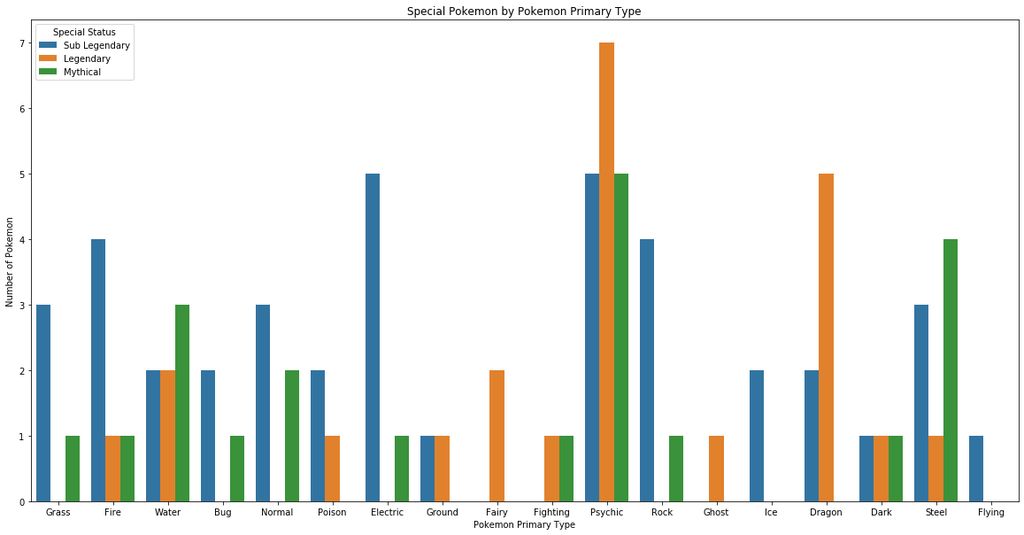

```python
plt.figure(figsize=(20,10))
g = sb.countplot(data = pokemon, x = 'type_1', hue = 'special_status');
plt.ylabel('Number of Pokemon')
plt.xlabel('Pokemon Primary Type')
plt.title('Special Pokemon by Pokemon Primary Type')
g.legend(title='Special Status');
```

Psychic type has the most "special" Pokemon, with the highest number of Sub Legendary (tied with Electric for 5), Legendary (7), and Mythical (5) Pokemon overall. However, this is actually yet another point in contention for showing balance in Pokemon, because Psychic types are not inherently stronger than the other types when looking at total stat distributions. Dragon types are the ones that have the slight edge - so Psychic's abundance of Special Pokemon ultimately did not cause a power imbalance in their favor.

# Conclusion

As a franchise that has achieved numerous success over the past 24 years, Pokemon shows its experience in designing and maintaining strong balance amongst all of its hundreds of Pokemon, as demonstrated by its ability to balance Pokemon stats and strength across type, generation, and special status.